# Lab 3: Graphics and descriptive statistics using R

13. Repeat the tasks in question 10, but this time vary the number of trials while keeping the sample size constant at 90. What happens to the mean of our samples as the number of trials increases compared to the mean for the entire population?

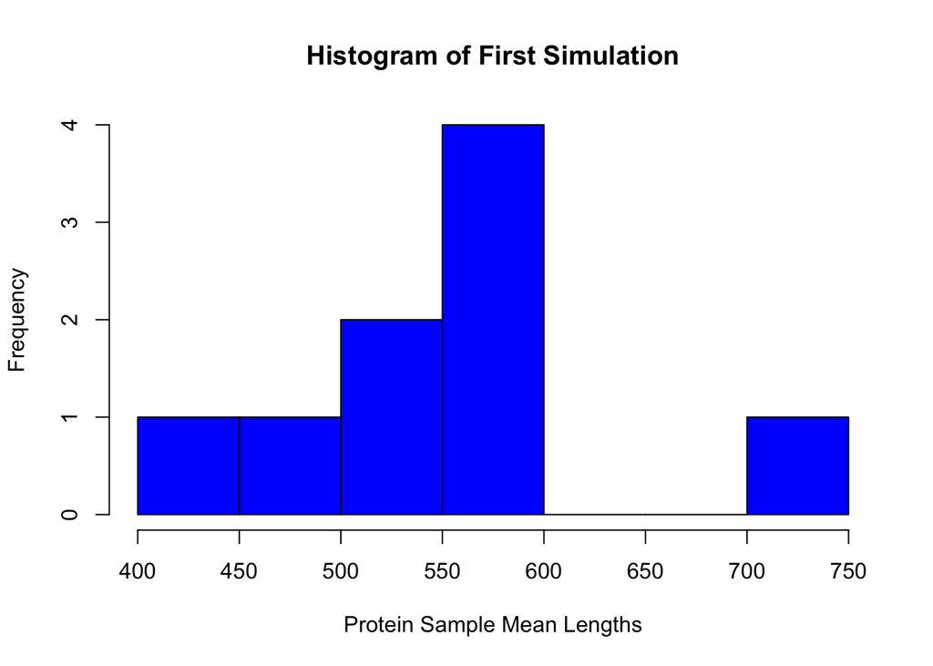

```r
size1 <- 9
size2 <- 90
size3 <- 900
size4 <- 9000
trials <- 90

firstSim <- funkySampler(proteinDataVec,trials,size1)
secSim <- funkySampler(proteinDataVec,trials,size2)
thirdSim <- funkySampler(proteinDataVec,trials,size3)
fourthSim <- funkySampler(proteinDataVec,trials,size4)
hist(firstSim,main="Histogram of First Simulation",col="blue", xlab="Protein Sample Mean Lengths")
```

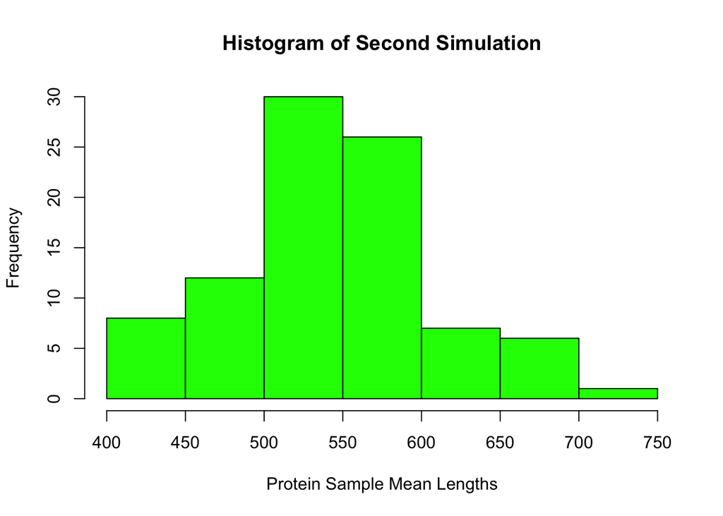

```r
hist(secSim,main="Histogram of Second Simulation",col="green", xlab="Protein Sample Mean Lengths")
```

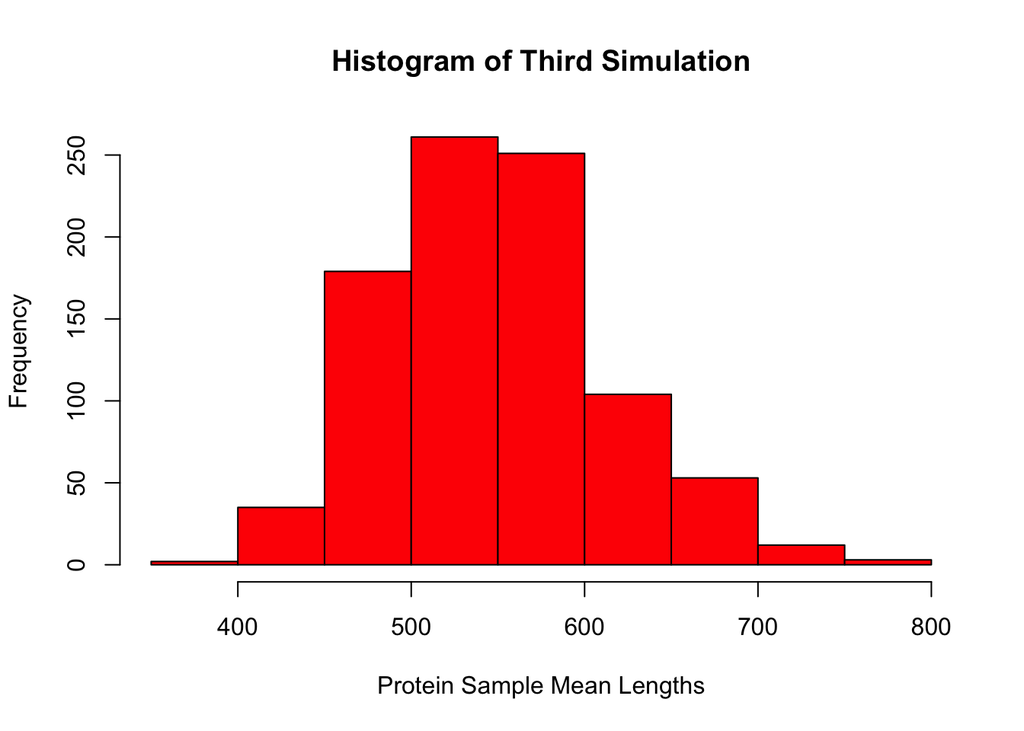

```r
hist(thirdSim,main="Histogram of Third Simulation",col="red", xlab="Protein Sample Mean Lengths")
```

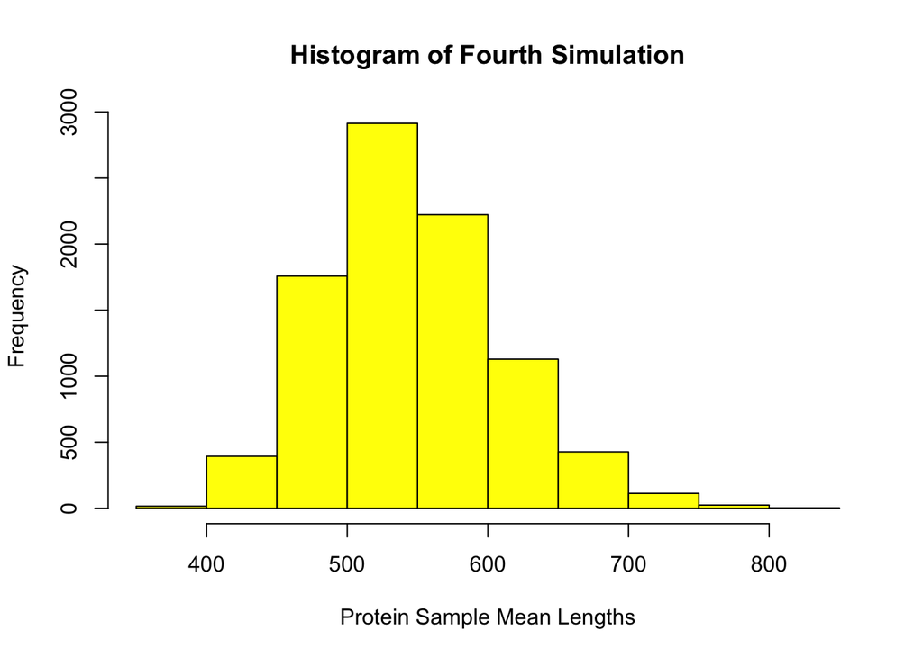

```r
hist(fourthSim,main="Histogram of Fourth Simulation",col="yellow", xlab="Protein Sample Mean Lengths")
```

```r
print(paste("Mean of First Simulation:",mean(firstSim)))
```

```
## [1] "Mean of First Simulation: 541.571604938272"
```

```r
print(paste("Mean of Second Simulation:",mean(secSim)))
```

```
## [1] "Mean of Second Simulation: 545.220987654321"
```

```r
print(paste("Mean of Third Simulation:",mean(thirdSim)))
```

```
## [1] "Mean of Third Simulation: 548.93975308642"
```

```r
print(paste("Mean of Fourth Simulation:",mean(fourthSim)))
```

```
## [1] "Mean of Fourth Simulation: 545.893008641975"
```

14. Which one is more important in obtaining a better precision, the number of trials or the sample size? Explain.

If you have a very small sample size, your precision error is going to be high, doesn’t matter how many trials you do. But if you pick a large sample, you should get a value very close to the true mean of the population. Thus, sample size is more important, because when you keep the number of trials constant and change the sample size, the histograms get a lot of error in their precision.

15. Modify your function so that instead of finding the mean for each trial inside the for loop, calculate the standard error (estimate) for each trial using your function from question 8. Run simulations using the sample sizes and the number of trials from question 10. For these simulations, each item in the results vector is the standard error for one of the samples we took from the population. Find the mean of the results vector for each sample size and plot a histogram for each case; descibe the pattern.

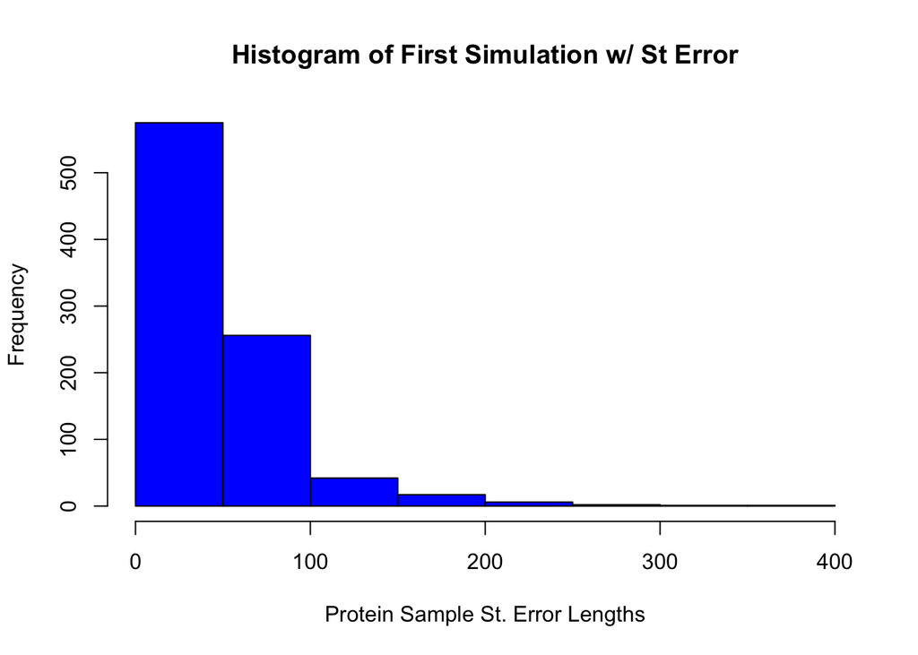

```r
vectorOfInterest <- c(1:1000)
sampleSize <- 10
nTrials <- 1000

funkySamplerTwo <- function(dataset, sample, n){
    results <- numeric(n)
    for(i in 1:n){
        vectorSample <- sample(dataset, sample)
        results[i] <- stError(vectorSample)
    }
    return(results)
}

size1 <- 9
size2 <- 90
size3 <- 900
size4 <- 9000
trials <- 900

firstSim <- funkySamplerTwo(proteinDataVec,size1,trials)
secSim <- funkySamplerTwo(proteinDataVec,size2,trials)
thirdSim <- funkySamplerTwo(proteinDataVec,size3,trials)
fourthSim <- funkySamplerTwo(proteinDataVec,size4,trials)
hist(firstSim,main="Histogram of First Simulation w/ St Error",col="blue", xlab="Protein Sample St. Error Lengths")
```

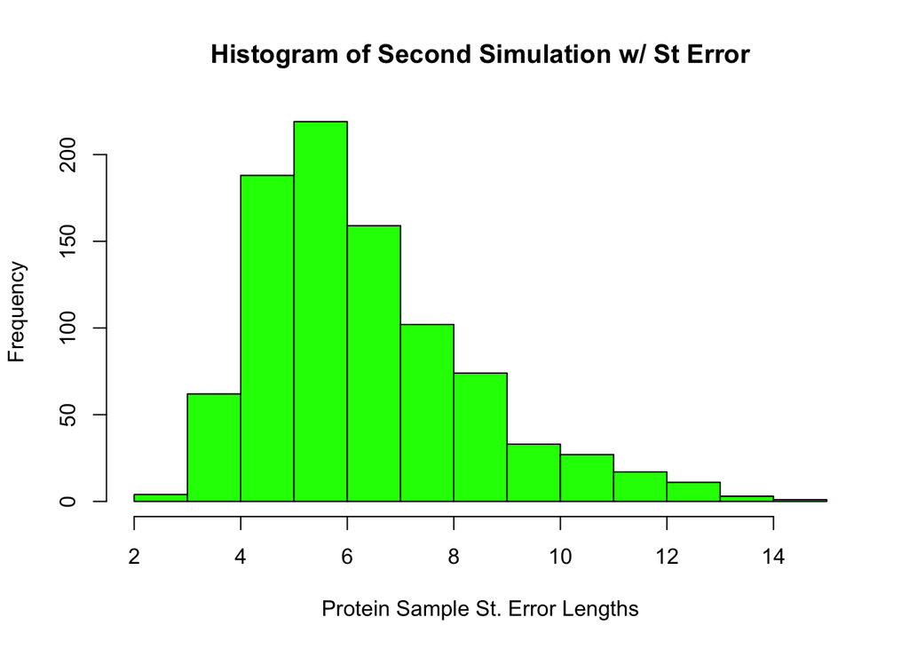

```r
hist(secSim,main="Histogram of Second Simulation w/ St Error",col="green", xlab="Protein Sample St. Error Lengths")
```

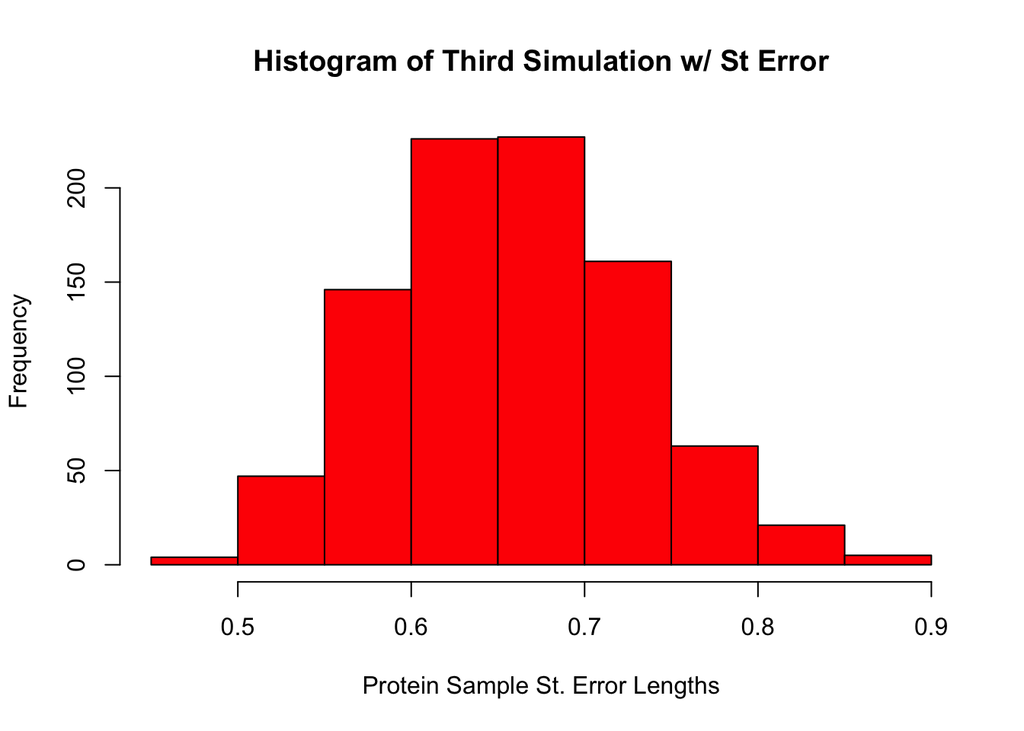

```r
hist(thirdSim,main="Histogram of Third Simulation w/ St Error",col="red", xlab="Protein Sample St. Error Lengths")
```

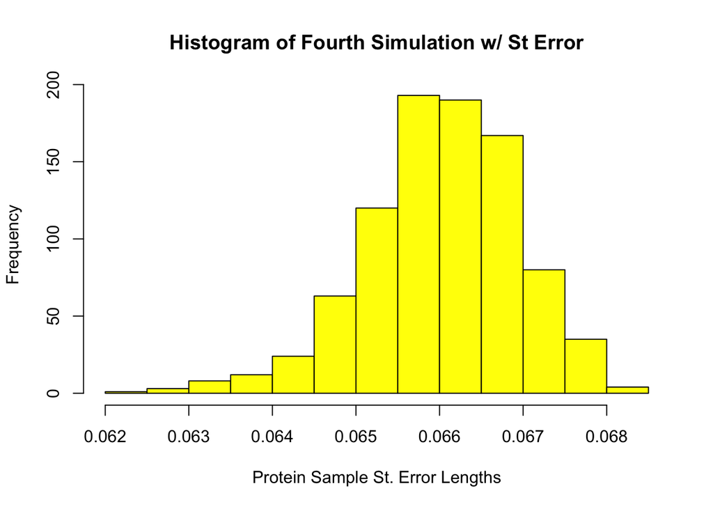

```r
hist(fourthSim,main="Histogram of Fourth Simulation w/ St Error",col="yellow", xlab="Protein Sample St. Error Lengths")
```

```r
print(paste("Mean of First Simulation:",mean(firstSim)))
```

```
## [1] "Mean of First Simulation: 50.8493321129139"
```

```r
print(paste("Mean of Second Simulation:",mean(secSim)))
```

```
## [1] "Mean of Second Simulation: 6.32278190274932"
```

```r
print(paste("Mean of Third Simulation:",mean(thirdSim)))
```

```
## [1] "Mean of Third Simulation: 0.658479963651254"
```

```r
print(paste("Mean of Fourth Simulation:",mean(fourthSim)))
```

```
## [1] "Mean of Fourth Simulation: 0.0660293923539021"
```

16. What happens to the mean of the standard errors as the sample size increases? The mean of the standard errors drops almost exponentially as the sample size increases.

## Data Frames and Factors

Let’s take a look at how our data needs to be formatted for proper statistical analyses. R has a set of built-in datasets, and we will be using one of them for this next section of the lab. To see R’s built-in datasets, we can execute the following command in the console.

```r
data()
```

Here we are looking for a data frame loaded into the variable `PlantGrowth`. As you learned last week, data frames are essentially tables that store information about each of our variables. Let’s take a look at its contents. Type the following command into your console.

```r
PlantGrowth
```

```
   weight group
1    4.17  ctrl
2    5.58  ctrl
3    5.18  ctrl
4    6.11  ctrl
5    4.50  ctrl
6    4.61  ctrl
7    5.17  ctrl
8    4.53  ctrl
9    5.33  ctrl
10   5.14  ctrl
11   4.81  trt1
12   4.17  trt1
13   4.41  trt1
14   3.59  trt1
```

[output cut: 16 more lines]

This shows the contents of `PlantGrowth`: one column for the plant weight, and one column for the group the plant was in (control, treatment 1, and treatment 2).

First, let’s determine the data types that are contained in PlantGrowth. The R function `class()` will return the data type of the argument it is given. For example,

```r
class(7)
```

```
[1] "numeric"
```

```r
class(TRUE)
```

```
[1] "logical"
```

```r
class(seq(1, 5, 0.1))
```

```
[1] "numeric"
```

So even if a vector is passed to `class()`, it will return the data-type that the vector contains.

Now let’s apply the same function on the columns of our `PlantGrowth` data frame:

```r
names(PlantGrowth)
```

```
[1] "weight" "group"
```

```r
class(PlantGrowth$weight)
```

```
[1] "numeric"
```

```r
class(PlantGrowth$group)
```

```
[1] "factor"
```

So what is a factor? Factors are a way to represent categorical variables in R, particularly in data frames. In `PlantGrowth` each row contains the weight of a plant (a numeric value) as well as the group to which that plant belongs (a factor). In this case, the factors are the control group (`ctrl`), the first treatment group (`trt1`), and the second treatment group (`trt2`). Factors make it easy to store data from multiple groups in the same data frame. Note that factors are very important for performing many analyses in R!

17. The command to make a boxplot in R is:

```r
boxplot(response variable ~ explanatory variable)
```

Make a box plot using plant growth data frame where `weight` is the response variable and `group` is the categorical explanatory variable. Title the graph “Boxplot of Dataset PlantGrowth” and label the x and y axes “Treatment Method” and “Plant Weight”, respectively (this is similar how we added labels and titles for histograms and scatter plots).

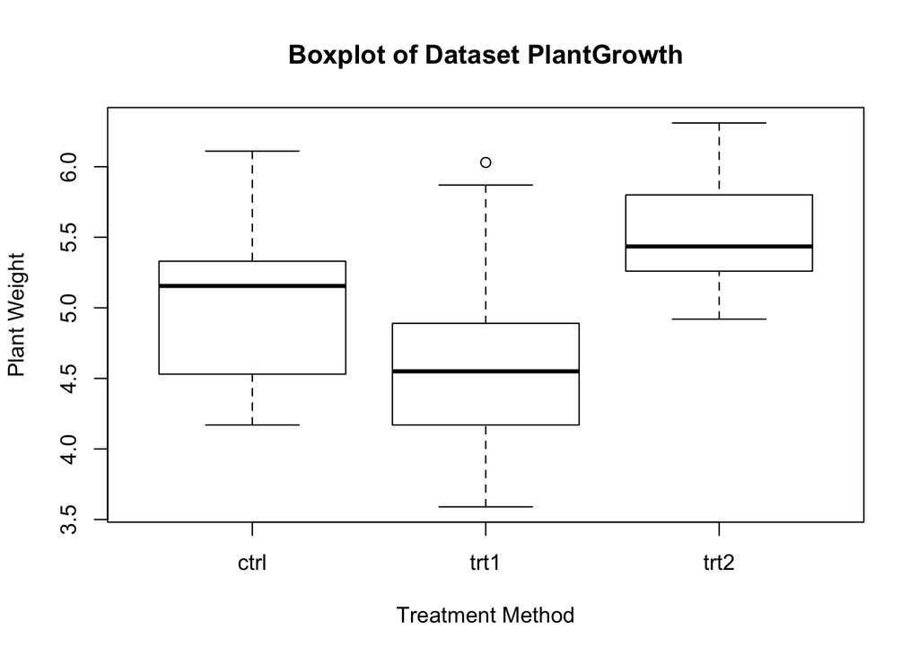

```r
boxplot(PlantGrowth$weight ~ PlantGrowth$group, main="Boxplot of Dataset PlantGrowth", xlab="Treatment Method",ylab ="Plant Weight")
```

18. Describe the different descriptive statistics captured by the boxplot. What do the whiskers represent? The box? The dark line within the box? Which treatment seems more effective?

Median (the value separating the higher half and lower half of a population or sample) First Quartile (median of lower half of data), Third Quartile (median of upper half of data), Minimum (lowest value within 1st quartile - IQ Range(1.5)), Maximum(highest value within 3rd quartile + IQ Range(1.5)), the InterQuartile Range (3rd quartile - 1st quartile), Outliers(values outside of the maximum and minimum). Whisker’s are the lines extending from the boxes (3rd and 1st quartiles). They are used to indicate variability outside the lower and upper quartile.

We can execute functions over data assigned to factors by using the `aggregate()` function. This is particularly useful when we want to obtain summary data such as the mean.

```r
aggregate(PlantGrowth$weight, by=list(PlantGrowth$group), FUN=sd)
```

```
  Group.1         x
1    ctrl 0.5830914
2    trt1 0.7936757
3    trt2 0.4425733
```

```r
aggregate(PlantGrowth$weight, by=list(PlantGrowth$group), FUN=var)
```

```
  Group.1         x
1    ctrl 0.3399956
2    trt1 0.6299211
3    trt2 0.1958711
```

19. Use the `aggregate` function to calculate the range, standard deviation and standard error for each of the groups in `PlantGrowth`.

```r
aggregate(PlantGrowth$weight, by=list(PlantGrowth$group), FUN=sd)
```

```
##   Group.1         x
## 1    ctrl 0.5830914
## 2    trt1 0.7936757
## 3    trt2 0.4425733
```

```r
aggregate(PlantGrowth$weight, by=list(PlantGrowth$group), FUN=stError)
```

```
##   Group.1          x
## 1    ctrl 0.05830914
## 2    trt1 0.07936757
## 3    trt2 0.04425733
```

## Review

| Operation | Syntax in R |
| --- | --- |
| Sample n random numbers between 1 and 0 from the uniform distribution | `runif(n)` |
| Sample n random numbers from the normal distribution | `rnorm(n)` |
| Plot `y` as a function of `x` | `plot(x,y)` |
| Histogram | `hist(x)` |
| Number of columns in data frame | `ncol(dataframe)` |
| Number of rows in data frame | `nrow(dataframe)` |
| Create a vector with n zero entries | `numeric(n)` |
| Class of a variable | `class()` |
| Box plot | `boxplot(response variable ~ explanatory variable)` |
| Variance | `var()` |
| Execute a function for individual factors | `aggregate()` |

## Lab 3 Homework

For all of the problems below you should use RStudio to answer the questions in this document. Please show all of your commands to read the data, plot and perform analysis. The homework is due one week after your lab day at 1:30pm on Chalk.

## Confidence Intervals from a normal distribution

As you will learn in lecture, confidence intervals help us gauge the reliability of an estimate. Assuming we have an estimate of the mean and standard deviation of a population, for a normal distribution we can calculate the 95% confidence interval as follows:

```r
sampleMean <- 10
SD <- 3
n <- 30
error <- qnorm(0.975) * SD / sqrt(n)
lower <- sampleMean - error #lower value of the 95% confidence interval
upper <- sampleMean + error # upper value of the 95% confidence interval
CI95 <- c(lower, upper)
CI95
```

```
[1]  8.926484 11.073516
```

We’ll talk more about the command `qnorm()` in a later lab, but for now what you need to now is that `qnorm(0.975)` gives the x-value for which the area under the standard normal distribution is 97.5% of the total area under the curve (which is 1).

```r
qnorm(0.975)
```

```
[1] 1.959964
```

[figure not shown]

1. Why did we use `qnorm(0.975)` instead of `qnorm(0.95)` to find the 95% confidence interval?

2. Use the code above to write a function for the 90% confidence interval. Use this function and the `aggregate()` command to calculate the 90% confidence interval for each of the groups in `PlantGrowth` data.

3. Modify your function from question 21 to write a function for the 99% confidence interval. Calculate the 99% confidence interval for all the groups in `PlantGrowth`. Compare to the 90% confidence intervals, which one is smaller? Why?

4. We’re going to take another look at the dengue DNA sequence that we started analyzing for lab 1. After setting your working directory to the folder where you have saved the dengue sequence file, run the following commands in R:

```r
library('seqinr')
dengue <- read.fasta(file = 'dengue_seq.txt')
dengue_vec <- as.vector(dengue[[1]])
```

(a) Write a **single function** called `GC_content` that takes in a sequence and calculate the GC content of the sequence. You can refer to your code from homework 1 for help, but make sure your final code is written as a function.

(b) Recall our sampling function `funkySampler()` given in the lab above. Modify the function so that, for each sample that you take, you use your function from part (a) to calculate the GC-content of that sample (note that we will now be sampling from a character vector). Return the vector of these sample GC contents. Write your function below.

(c) Use your code from part (b) and perform four different simulations where you sample from `dengue_vec` using a sample size of 9, 90, 900, and 9000. Keep the number of trials at 900 for each simulation. For each simulation, plot a histogram of the results vector and calculate the mean of the results vector. Describe how the distribution of the results changes as the sample size changes.

(d) For each simulation, how do the means of your samples compare to the GC-content for the dengue DNA sequence as a whole?

5. Read data from the file *MeaslesOutbreaks.csv* into R with the `read.csv()` command. Choose an appropriate variable name for this command. This data comes from Example 2.4A in the Whitlock Schluter textbook.

(a) Use the `plot()` command you learned in lab to plot a graph using `yearByQuarter` as the explanatory variable and `confirmedCases` as the response variable. Make sure to include axis labels and a title.

(b) Add the parameter `type="l"` to your `plot()` command from part (a). How does this change your graph?